# Percentage Difference in Contributions in and out of the State

Christina Lyu & Sicong Li (using Github[^1])

start: 3/7/2018; last modified: 3/23/2018

The amount of campaign funding can indicate a candidate’s ability to find, communicate with and cultivate supporters. In the 2012 presidential election, President Obama, the Democratic Party, and supportive outside groups raised more than $1.1 billion in his victorious campaign. In recent years, political engagement across state lines has increased dramatically, and only Alaska and Hawaii impose any limits on out-of-state contributions, while there is no state limits out-of-state expenditures.

Therefore, we want to analyze the difference between inflow and outflow of the contributions in each state and the total contribtions in each state.

```r
#join two data frames: committees and contributions
joined <-
  committees %>%
  #use left join to keep the information in contributions and put the information in committees in the left
  left_join(contributions, by = "cmte_id")

#create new dataframe group_id with the comittees grouped by the name and state
group_id <-
  joined %>%
  #group the committees by name, and if they have the same name group them by their state
  group_by(cmte_id, cmte_state) %>%
  #summarise the dataframe
  summarise(
    #number of contributions made
    amount = n(),
    #get the number of contributions made to inside of the state
    same = sum(ifelse(state == cmte_state, 1, 0)),
    #contributions to outside of the state
    diff = amount - same)
```

```r
group_summary <-
  group_id %>%
  #select the rows where same is not NA
  filter(!is.na(same)) %>%
  #put committees for each state together
  group_by(cmte_state) %>%
  #summarise the groups with the total contributions, and the inState, outState contributions and calculate the percentage
  summarise(total = sum(amount),
         inState = sum(same),
         outState = sum(diff),
         percentageIn = inState / total,
         percentageOut = outState / total)

group_summary
```

```
## # A tibble: 55 x 6
##    cmte_state  total inState outState percentageIn percentageOut
##    <chr>       <int>   <dbl>    <dbl>        <dbl>         <dbl>
##  1 AK             83    20.0     63.0       0.241          0.759
##  2 AL           1441   402     1039         0.279          0.721
##  3 AR           1800   162     1638         0.0900         0.910
##  4 AZ           1567   415     1152         0.265          0.735
##  5 CA          19007  7119    11888         0.375          0.625
##  6 CO           3141   407     2734         0.130          0.870
##  7 CT           2223   297     1926         0.134          0.866
##  8 DC         206404 24175   182229         0.117          0.883
##  9 DE            711    42.0    669         0.0591         0.941
## 10 FL           7669  3736     3933         0.487          0.513
## # ... with 45 more rows
```

```r
group_summary %>%
  #summarise the previous dataframe by the mean of the percentage in State and out of State
  summarise(all = sum(total),
            inS = sum(inState),
            outS = sum(outState),
            meanIn = inS / all,
            meanOut = outS / all
            )
```

```
## # A tibble: 1 x 5
##      all   inS   outS meanIn meanOut
##    <int> <dbl>  <dbl>  <dbl>   <dbl>
## 1 396369 61888 334481  0.156   0.844
```

```r
group_summary %>%
  #select the rows with the fewest or the most inState contributions
  filter(percentageIn == max(percentageIn) |
           percentageOut == max(percentageOut))
```

```
## # A tibble: 2 x 6
##   cmte_state total inState outState percentageIn percentageOut
##   <chr>      <int>   <dbl>    <dbl>        <dbl>         <dbl>
## 1 PR             6       0     6.00        0             1.00
## 2 WV           728     621   107           0.853         0.147
```

From the result of the dataset, among the states we are analyzing, the District of Columbia has the largest contribution in and out of the total. Overall, there is a mean of 15.61% contributions to committees in the same state and a mean of 84% contributions to other states. Therefore, most states contribute to committees out of state. From the dataset, we can also get the information that most of the contributions in West Virginia are made to committees within the state, and all of the contributions in Puerto Rico are made to committees outside the state.

```r
percentage <-
  joined %>%
  #select rows in which transaction_amt is not NA
  filter(!is.na(transaction_amt)) %>%
  #group the dataframe by the state
  group_by(cmte_state) %>%
  #add a colomn called total representing the total amount of transactions
  mutate(total = sum(transaction_amt))

getPercentage <- function(data) {
  data %>%
    #add columns of sumOut representing the total amount of transaction outside the state and its percentage in the total
    mutate(sumName = sum(transaction_amt),
           percentName = sumName / total) %>%
    select(cmte_state, total, sumName, percentName)
}

percentageIn <-
  percentage %>%
  filter(cmte_state == state) %>%
  getPercentage() %>%
  select(cmte_state, sumName, percentName)

colnames(percentageIn) <- c("cmte_state", "sumIn", "percentIn")

#remove duplicate rows
percentageIn <-
  percentageIn[!duplicated(percentageIn), ]

percentageOut <-
  percentage %>%
  #select the rows where the donation is made to the different states as the committee
  filter(cmte_state != state) %>%
  getPercentage()

colnames(percentageOut) <- c("cmte_state", "total", "sumOut", "percentOut")

#remove duplicate rows
percentageOut <-
  percentageOut[!duplicated(percentageOut), ]

#join the two dataframe
percentage_all <- percentageIn %>%
  full_join(percentageOut, by = "cmte_state")
```

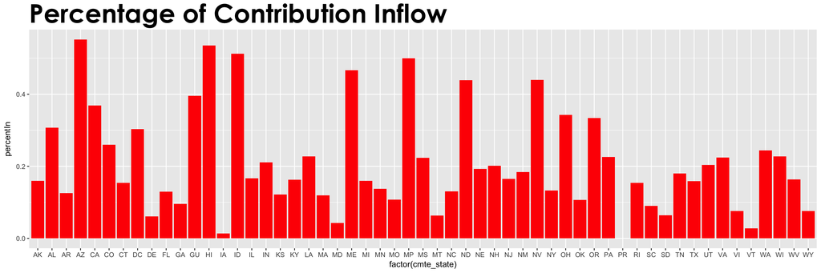

```r
#making a bar plot for each state and the percentage of transmissions within the state
bar_plot <-
  percentage_all %>%
  ggplot(aes(x = factor(cmte_state))) +
  geom_bar(aes(x = factor(cmte_state), y = percentIn), stat = "identity", fill = "red") +
  ggtitle("Percentage of Contribution Inflow")+
  #make the font and the bold of the title
  theme(plot.title = element_text(family = "Century Gothic", color="Black", face="bold", size=34, hjust=0))
bar_plot
```

To analyze the data, we joined dataset *committees* and *contributions* together by committees ID. Then we calculated the sum of transaction inside and outside each state. Looking at the bar plot, we can see that except four regions, which are Arizona, Hawaii, Idaho, and the Northern Mariana Islands, most of the regions have contributions inflow smaller than 50%. This indicates that over half of the money transaction in most of the states is out-of-state transactions. Considering there are 55 regions in total in our dataset, the in-state transaction is the highest among the all, which makes sense as people cares more about their rights in their states.

There is no transaction inflow in Puerto Rico. We think this could be explained by the political voting right of Puerto Rico. Residents in Puerto Rico are not entitled to electoral votes for President. In the U.S. House of Representatives, Puerto Rico is entitled to a Resident Commissioner, a delegate who is not allowed to vote on the floor of the House.

Among all the states who do contribute to committees within the states, Iowa has the lowest rate. We found it is noteworthy as Iowa is one of the swing states.

```r
#make a list of state names
state_list <- c("Alabama",
"Alaska",
"Arizona",
"Arkansas",
"California",
"Colorado",
"Connecticut",
"Delaware",
"Florida",
"Georgia",
"Hawaii",
"Idaho",
"Illinois",
"Indiana",
"Iowa",
"Kansas",
"Kentucky",
"Louisiana",
"Maine",
"Maryland",
"Massachusetts",
"Michigan",
"Minnesota",
"Mississippi",
"Missouri",
"Montana",
"Nebraska",
"Nevada",
"New Hampshire",
"New Jersey",
"New Mexico",
"New York",
"North Carolina",
"North Dakota",
"Ohio",
"Oklahoma",
"Oregon",
"Pennsylvania",
"Rhode Island",
"South Carolina",
"South Dakota",
"Tennessee",
"Texas",
"Utah",
"Vermont",
"Virginia",
"Washington",
"West Virginia",
"Wisconsin",
"Wyoming")
#get the states map from map_data
states <- map_data("state")
```

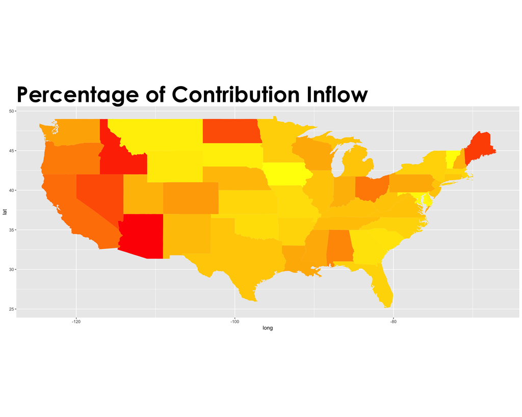

```r
#change all the state name to lowercase to corresponde with the state names in the dataset, because I found the list from the internet and copied it to the code
i <- 1
stateLower <- list()
for (state in state_list){
  lower <- tolower(state)
  stateLower[[i]] <- lower
  i <- i + 1
}
#change the state name to teh abbreviation of the state as appeared in cmte_state
for(i in seq_along(stateLower)){
  states[ , 5 ][ states[ , 5 ] == stateLower[i] ] <- state.abb[grep(state_list[i], state.name)]
}
#add the column to the states dataset
states$cmte_state <- states$region

map_per <- inner_join(states, percentage_all, by = "cmte_state")
#remove duplicate rows
map_per <-
  map_per[!duplicated(map_per), ]

#make a function to draw maps with color density
mapGraph <- function(fillV, color1, color2, title) {
  ggplot() +
    #add a theme
    theme(legend.position="none") +
    #draw the map and fill it with color
    geom_map(data=map_per, map=map_per, aes(map_id=cmte_state, x = long, y = lat, fill=fillV)) +
    #make the color the same color indicated when calling the function
    scale_fill_gradient(low = color1, high = color2, guide = "colourbar") +
    coord_equal() +
    ggtitle(title)+
  #make the font and the bold of the title
    theme(plot.title = element_text(family = "Century Gothic", color="Black", face="bold", size=45, hjust=0))
}
#draw the percentageIn map
gg <-
  mapGraph(map_per$percentIn, "yellow", "red", "Percentage of Contribution Inflow")
gg
```

We then mapped the percentIn on a geographical map. It shows that Maine and states in the west coast overall have relatively higher percentIn, while states in the central America have relatively lower percentIn. However, among those states, North Dakota stands out from the states surrounded with the percentIn of 44%.

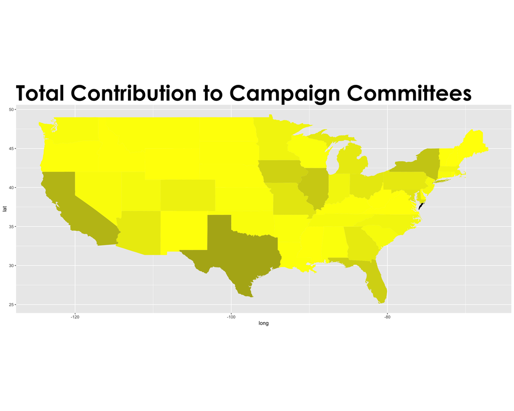

```r
#draw the total map
gg2 <-
  mapGraph(map_per$total, "yellow", "black", "Total Contribution to Campaign Committees")
gg2
```

[^1]: Github link: https://github.com/ChristinaLyu/miniProject2.git